# HLM Tutorial

PSYC5513

19/02/2022

In this tutorial we’ll be going through an example of Hierarchical Linear Modelling (HLM) following the same method as Field uses in *Learning Statistics Using R*. So, if you haven’t already, please read through 19.1 - 19.6 in that text. **Note:** When I say that we’ll follow the same method as Field, there will be some slight differences, including interpreting the models in a slightly different way to Field.

Essentially, HLM is an extension of regular regression you’re probably already familiar with. The aim in regression is usually to estimate an intercept on the outcome variable, and one (or more) slope(s) capturing the strength and nature of the relationship between predictor and outcome variables. HLM does this too, but takes it further in allowing these slopes and intercepts to vary based on clustering at different levels.

In this worked example, we have a dataset measuring **workplace deviance behaviour** amongst **individuals in different branches** of an organisation (MegaBank).

We’re interested in understanding whether *negative affect* (measured at the individual level) and/or *rule enforcement climate* (measured at the group level) are related to workplace deviance.

HLM can help us answer two types of questions:  
1. Do the slopes and intercepts vary across groups (in this case bank branches)?  
2. Can we use group-level variables to account for the variance in the slopes and intercepts?

In ordinary (multiple) regression, we assume each individual’s observation is independent, which may be unrealistic. Our example provides a case where HLM is useful, because individuals are *not* independently observed, but are instead clustered into MegaBank branches. We may expect, for example, that individuals in different branches have different intercepts (i.e., baseline levels of workplace deviance).

We may also want to see whether our group-level variable (rule enforcement climate) can impact deviance, and affect the relationship between negative affect and deviance. Investigating *both* group *and* individual-level effects is possible with HLMs.

# 1 Install and load packages

```r
rm(list = ls())  # clear the workspace of all objects

#if you haven't installed these packages yet, use the code below first. If you've already installed them, you can skip this step
#install.packages("ggplot2")
#install.packages("nlme")
#install.packages("effects")

#Once you've installed these packages, you need to load them using the code below.
library(ggplot2)
library(nlme)
library(effects)
```

# 2 Research Questions/ Hypotheses

Before we start, it’s a good idea to come up with some concrete research questions and hypotheses. I’ve bolded the ones that typically count as the “real” hypotheses.

1. Branches differ in their baseline levels of workplace deviance.
   - I’d hope to find a statistically significant *random intercept* effect.
2. **H1: Negative affect is positively associated with workplace deviance.**
   - If this were supported, I’d expect that the *fixed effect for the (Level 1) negative affect predictor* is significant.
3. **H2: There are between-branch differences in the relationship between negative affect and workplace deviance.**
   - If this were supported, I’d expect a statistically significant *random slope* for *negative affect*.
4. **H3: Rule enforcement climate relates negatively to workplace deviance. That is, in branches with stronger rule enforcement climate, we will see less workplace deviance .**
   - If this were supported, I’d expect that the *fixed effect for the (Level 2) rule enforcement predictor* is significant.
   - If this were supported, I’d expect that some of the *random intercept variation* can now be explained by rule enforcement climate, and therefore, that the size of this random effect is reduced.
5. **H4: Rule enforcement climate moderates the relationship between negative affect and workplace deviance. More specifically, in higher rule enforcement climates, there will be a weaker association between negative affect and workplace deviance (flatter line). Alternatively, in lower rule enforcement climates, there will be a stronger association between negative affect and workplace deviance (steeper line).**
   - If this were supported, I’d expect that the *fixed, cross-level rule enforcement climate by negative affect effect* is significant.
   - If this were supported, I’d expect that some of the *random slope* for *negative affect* can be explained by the cross-level interaction effect, and therefore that the size of this random slope for negative affect is reduced.

# 3 Data Loading and Visualisation

The dataset contains observations from 323 individuals within MegaBank branches, with numerous columns for variables, detailed in the *Deviance Data Guide* at the end of this document.

Let’s load the dataset, calling it `deviance_data`.

```r
deviance_data <- readRDS('deviance_data.rds')
```

Ok, so now we’ve loaded our data, it’s a good idea to have a look at our data to get a feel it. Given that we’re expecting the relationship between negative affect and workplace deviance to vary between bank branches, it’s worth checking to see if it looks like this is the case.

To do this, we can plot the relationship between negative affect and workplace deviance, with a separate plot for each Megabank branch. We can do this using the package `ggplot2`.

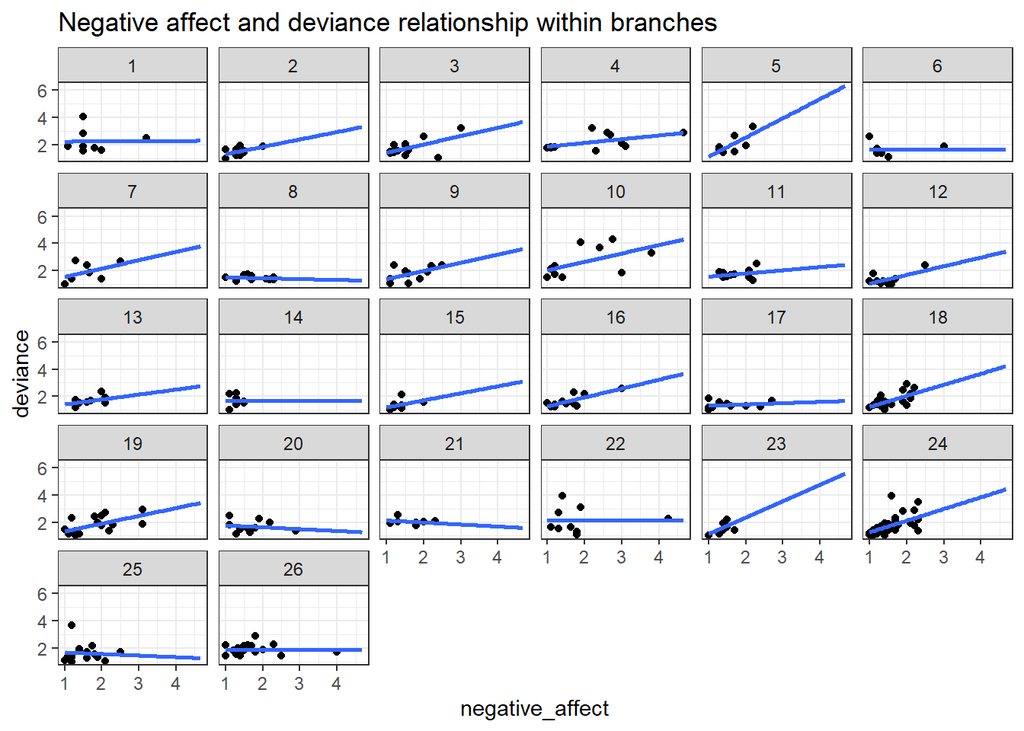

```r
ggplot(deviance_data, aes(x = negative_affect, y = deviance)) +
  geom_point() +
  stat_smooth(method = "lm",      # Calculate a regression line
              se = FALSE,         # Drop the confidence bands for now
              fullrange = TRUE) +   # Make the line stretch across plot
  facet_wrap( ~ branch_no) +      # Create separate plot for each branch
  labs(title = "Negative affect and deviance relationship within branches") + #Add a title
   theme_bw()
```

As we can see from these plots, it appears there is some variability between branches in the relationship between negative affect and deviance. For example, in branch 5 there appears to be quite a strong positive relationship, whereas in branches 20 and 21 there appears to be a slight negative relationship. This is good news for us as that’s what we were expecting to see.

# 4 Model building

To test whether the between-branch variability we saw in the plots above is significant we’ll need to use HLM. To do this, we’ll take a step-by-step approach in building our multilevel model. That is, we fit a series of models, one-at-a-time, each time testing to see if the new model is a better fit to the data.

## 4.1 Step 1: Check whether we even need to do HLM (Random intercept model)

The first step in doing HLM is to determine if there is significant variation across contexts (i.e., bank branches). If there isn’t, then we don’t need to worry about doing HLM at all, we could just use regression/ ANOVA.

To do this, we need to firstly fit a baseline model which includes only the intercept. Next, we fit another model which allows the intercepts to vary between Megabank branches. Finally, we compare these two models to see if the second model fits our data better.

First things first, lets fit the baseline model using only the intercept. We do this by using the function `gls()` which is very similar to the `lm()` you will have used before. We’re fitting a model called `null_model`, within which we:

1. Specify that we want `deviance` to be predicted by the intercept (represented by the 1 in our function).
2. Specify which dataset we want to use.
3. Specify that we want to use maximum likelihood (ML) estimation. HLM models are much more involved than traditional regressions, so we usually use either ML or restricted ML (REML) methods. Both are more complex than can be explained here, but ML will allow us to compare models later.

```r
null_model <-gls(deviance ~ 1,
                    data = deviance_data,
                    method = "ML", #Specifying that we'll use Maximum Likelihood (ML) estimation
                    na.action = na.omit)

summary(null_model)
```

```
## Generalized least squares fit by maximum likelihood
##   Model: deviance ~ 1
##   Data: deviance_data
##        AIC      BIC    logLik
##   598.5706 606.1259 -297.2853
##
## Coefficients:
##                Value  Std.Error  t-value p-value
## (Intercept) 1.768861 0.03384966 52.25639       0
##
## Standardized residuals:
##        Min         Q1        Med         Q3        Max
## -1.2658014 -0.6181629 -0.2005269  0.3805319  4.1574143
##
## Residual standard error: 0.6074104
## Degrees of freedom: 323 total; 322 residual
```

Now we want to fit the same model, but let the intercepts vary across Megabank branches. We do this using the `lme()` function, which we’ll use for all the rest of our models too. The format is much the same as `gls()` above, except we need to add a `random` argument, which says that we want the intercept to very by group (in model terms we write `1 | branch_no`).

```r
model_1 <-lme(fixed = deviance ~ 1,
                          data = deviance_data,
                          random = ~1|branch_no, #The new part, saying we want intercepts to vary between branches (i.e., random intercepts)
                          method = "ML",
                          na.action = na.omit)

summary(model_1)
```

```
## Linear mixed-effects model fit by maximum likelihood
##   Data: deviance_data
##        AIC      BIC    logLik
##   589.4486 600.7816 -291.7243
##
## Random effects:
##  Formula: ~1 | branch_no
##         (Intercept)  Residual
## StdDev:   0.2090071 0.5750295
##
## Fixed effects:  deviance ~ 1
##                Value  Std.Error  DF  t-value p-value
## (Intercept) 1.776714 0.05323093 297 33.37748       0
##
## Standardized Within-Group Residuals:
##        Min         Q1        Med         Q3        Max
## -1.5828337 -0.6415288 -0.2545059  0.3862559  3.7966780
##
## Number of Observations: 323
## Number of Groups: 26
```

We asked for the intercept to vary by branch, so let’s check out what our model says the intercepts are. We can get these by calling `coef()` on our model. We’ll just inspect the first several by using `head()`:

```r
head(coef(model_1))
```

```
##   (Intercept)
## 1    2.019430
## 2    1.618405
## 3    1.875280
## 4    2.036659
## 5    1.883889
## 6    1.728054
```

We can see there’s some amount of variability in the intercept between groups.

Often what we want to check at this point are the variances for the intercept and the residuals. We can get that by calling `VarCorr()` on our model:

```r
var_model1 <- VarCorr(model_1)
var_model1
```

```
## branch_no = pdLogChol(1)
##             Variance   StdDev
## (Intercept) 0.04368395 0.2090071
## Residual    0.33065887 0.5750295
```

The `Variance` of `(Intercept)` here represents the between-branch intercept variance (i.e. at Level 2), and is 0.04. The variance of the within-branch residuals (i.e. at Level 1) is 0.33. Adding these two numbers, we have the *total variance* across both levels (within and between branches, roughly 0.37).

We can also pretty easily find the ratio of between to total variance to calculate the *intraclass correlation*.

```r
# Between-branch variance / Total variance
0.04368395 / (0.04368395 + 0.33065887)
```

```
## [1] 0.116695
```

This looks like a reasonable ICC, showing around 11.7% of variance in an individual’s workplace deviance is accounted for by which branch they work in.

Is it worth us using this model? The ICC informs us the branch has something to do with deviance, but we’d like to know whether intercepts vary *significantly* across branches (i.e., whether average deviance within a branch is significantly different across branches).

We can do this by comparing the two models we just created. To do this, we run a *likelihood ratio test* using the (somewhat confusingly named) `anova()` function on both models to see whether the random-intercept model fits the data better.

```r
anova(null_model, model_1)
```

```
##            Model df      AIC      BIC    logLik   Test  L.Ratio p-value
## null_model     1  2 598.5706 606.1259 -297.2853
## model_1        2  3 589.4486 600.7816 -291.7243 1 vs 2 11.12197   9e-04
```

Results indicate a likelihood ratio of $11.12$, with a p-value of $<.001$. Thus, the random-intercept model appears to fit better than an equal-intercept model, suggesting deviance intercepts vary significantly between branches.

So, to answer Research Question 1, Something about being in a particular branch does seem to determine how much deviance a person engages in!

## 4.2 Step 2: Add in fixed effects

We now know that baseline levels of deviance vary between bank branches but we also wanted to know if negative affect is related to workpalce deviance. We can do this using the same model we used above, but adding negative affect as a predictor of deviance.

```r
# Grand Mean Centre "negative affect" variable - this creates a new column in the data
deviance_data$negative_affect_centred <- with(deviance_data,
                                              scale(negative_affect,
                                                    center = TRUE,   # Do center
                                                    scale = FALSE))  # Don't Z-score

model_2 <-lme(fixed = deviance ~ 1 + negative_affect_centred, #We've added negative affect as a predictor
                                data = deviance_data,
                                random = ~1 | branch_no,
                                method = "ML",
                                na.action = na.omit)
summary(model_2)
```

```
## Linear mixed-effects model fit by maximum likelihood
##   Data: deviance_data
##        AIC      BIC    logLik
##   514.3591 529.3312 -253.1796
##
## Random effects:
##  Formula: ~1 | branch_no
##         (Intercept)  Residual
## StdDev:   0.1610908 0.5286171
##
## Fixed effects:  deviance ~ 1 + negative_affect_centred
##                             Value  Std.Error  DF  t-value p-value
## (Intercept)             1.7726244 0.04470607 285 39.65064       0
## negative_affect_centred 0.3884626 0.05494505 285  7.07002       0
##  Correlation:
##                         (Intr)
## negative_affect_centred -0.004
##
## Standardized Within-Group Residuals:
##        Min         Q1        Med         Q3        Max
## -1.9643234 -0.6150902 -0.1932725  0.4250499  4.1211900
##
## Number of Observations: 312
## Number of Groups: 26
```

We find that the *fixed effect* coefficient for centred negative affect is $.388$ and is significant ($p<.001$). This appears to support **Hypothesis 1**, but let’s just check that this model is a better fit to our data.

Once again, we can check the variances using `VarCorr()`.

```r
var_model2 <- VarCorr(model_2)
var_model2
```

```
## branch_no = pdLogChol(1)
##             Variance   StdDev
## (Intercept) 0.02595025 0.1610908
## Residual    0.27943600 0.5286171
```

Uisng the information above, we can calculate the ratio of residual (error) variance, $\sigma^2$, explained relative to model_1 by:

$$\frac{\sigma^2_{model.1}-\sigma^2_{model.2}}{\sigma^2_{model.1}}$$

```r
(0.33065887 - 0.27943600)/0.33065887
```

```
## [1] 0.1549115
```

Relative to the previous model (i.e., `model_1`) we fitted in Step 1 which did not include any predictors, this model (i.e., `model_2`) which included negative affect explained 15.5% more of the residual variance in deviance.

```r
#anova(model_1, model_2)
```

## 4.3 Step 3: Add in random slopes

So far we’ve seen that baseline deviance varies between branches and that negative affect is related to deviance. Next, we’ll want to check whether the relationship between negative affect and deviance varies between branches. From what we saw in the plots earlier, we expect this to be the case, but we’ll be checking it statistically now.

This step involves simply adding negative affect to the `random` section of the function we’ve used for the last few models, everything else about the model remains the same.

```r
model_3 <- lme(deviance ~ 1 + negative_affect_centred,
                    data = deviance_data,
                    random = ~ 1 + negative_affect_centred | branch_no, #Added negative affect here
                    method = "ML",
                    na.action = na.omit)

summary(model_3)
```

```
## Linear mixed-effects model fit by maximum likelihood
##   Data: deviance_data
##        AIC      BIC    logLik
##   513.5807 536.0387 -250.7904
##
## Random effects:
##  Formula: ~1 + negative_affect_centred | branch_no
##  Structure: General positive-definite, Log-Cholesky parametrization
##                         StdDev    Corr
## (Intercept)             0.1568487 (Intr)
## negative_affect_centred 0.2171811 0.267
## Residual                0.5154757
##
## Fixed effects:  deviance ~ 1 + negative_affect_centred
##                            Value  Std.Error  DF  t-value p-value
## (Intercept)             1.772817 0.04398640 285 40.30375       0
## negative_affect_centred 0.384754 0.07469104 285  5.15127       0
##  Correlation:
##                         (Intr)
## negative_affect_centred 0.152
##
## Standardized Within-Group Residuals:
##        Min         Q1        Med         Q3        Max
## -2.2286908 -0.5739762 -0.2047214  0.4257104  4.1980050
##
## Number of Observations: 312
## Number of Groups: 26
```

The plot below shows what we’ve done conceptually:

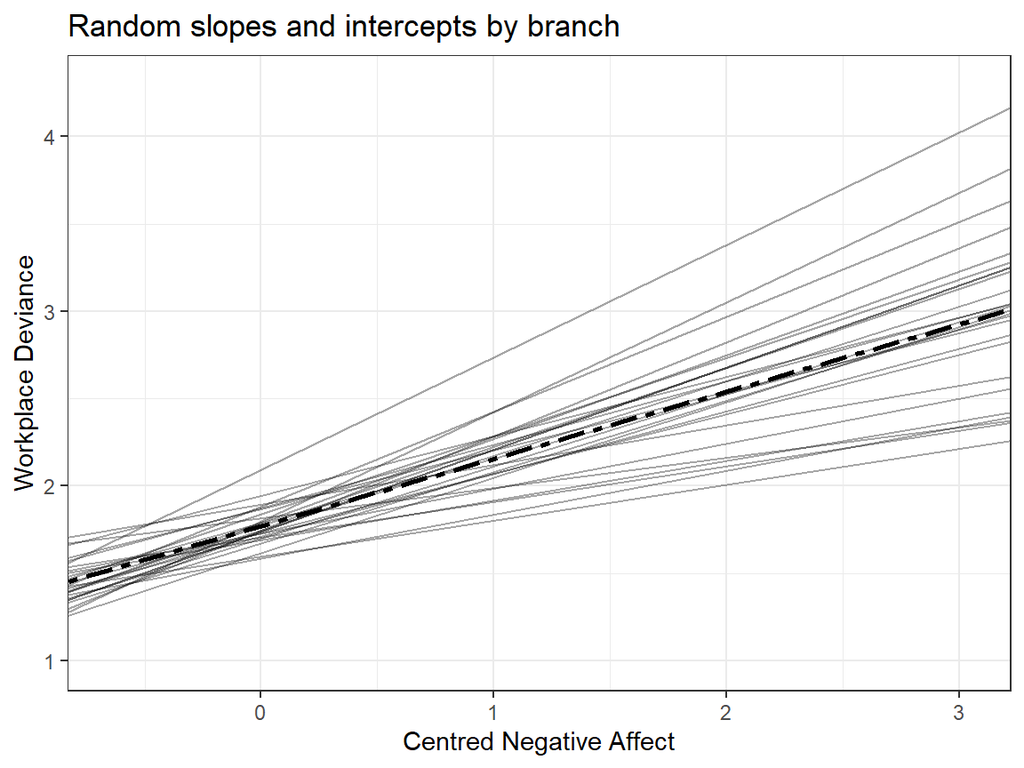

Each light grey slope is estimated by the model for a *single* branch. As you can see, some are stronger, and some are weaker, but all are generally positive. These are less extreme than what we saw earlier. This is a key benefit of using HLMs - we average across all the available data to get more realistic estimates (i.e., estimates that are less over-fitted). We’ve allowed the intercepts to vary by branch as well by putting `~ negative_affect_centred | branch_no` in the `random` argument.

The dashed black slope in the plot is the *fixed effect* estimate, intercept $=1.77$ and slope $=0.38$ as seen in the main model summary output above. This averages all these unique branch slopes and intercepts into one overall effect. Thus, we’ve ‘pooled’ across the branch variability and can say that negative affect appears to be positively related to workplace deviance.

We can inspect the variance components *with the predictors* from this first non-null model using `VarCorr()` again

```r
var_model3 <- VarCorr(model_3)
var_model3
```

```
## branch_no = pdLogChol(1 + negative_affect_centred)
##                         Variance   StdDev    Corr
## (Intercept)             0.02460150 0.1568487 (Intr)
## negative_affect_centred 0.04716764 0.2171811 0.267
## Residual                0.26571517 0.5154757
```

Next, we calculate the ratio of residual (error) variance explained relative to model 2.

```r
(0.27943600 - 0.26571517)/0.27943600
```

```
## [1] 0.04910187
```

Therefore, relative to model 2, our new model which allows the slopes to vary between branches explained 4.91% more of the residual variance in deviance.

Lastly, lets check again whether this improvement is statistically significant.

```r
anova(model_2, model_3)
```

```
##         Model df      AIC      BIC    logLik   Test  L.Ratio p-value
## model_2     1  4 514.3591 529.3312 -253.1796
## model_3     2  6 513.5807 536.0387 -250.7904 1 vs 2 4.778408  0.0917
```

These results suggest that adding random slopes to the model does not result in a significantly better fit ($p = .09$). Therefore, it seems that random slopes are not needed to explain this data. This is somewhat surprising given what we saw in the plots above but is perhaps a result of our smallish sample size. Although $N ~ 300$ and there are $>20$ groups, that works out to be an average of about 12 observations per group.

If we were doing these analyses in real-life we’d remove the random slopes from the model before proceeding but for the sake of this tutorial, we will leave them in to avoid over-complicating things.

## 4.4 Step 4: Add interaction effects

Now we want to test hypotheses 3 and 4 by introducing the Level 2 factor, rule enforcement climate, into our models.

What we’ll do first, to test **hypothesis 3**, is introduce rule enforcement climate as a predictor of workplace deviance. In doing this, we’re testing if our branch-level variable (rule enforcement climate) explains *why* there are differences in intercepts between groups.

Before we add rule enforcement climate to our model, we’ll grand mean center it as we did with negative affect earlier.

```r
#Grand Mean Centre group rule climate variable - creates a new column in the data
deviance_data$group_rule_centred <- with(deviance_data,
                                         scale(group_rule_climate,
                                               center = TRUE,
                                               scale = FALSE))

model_4 <- lme(fixed = deviance ~ 1 + negative_affect_centred + group_rule_centred, #added rule climate
                    data = deviance_data,
                    random = ~ 1 + negative_affect_centred | branch_no, #Removed negative affect
                    method = "ML",
                    na.action = na.omit)

summary(model_4)
```

```
## Linear mixed-effects model fit by maximum likelihood
##   Data: deviance_data
##       AIC     BIC    logLik
##   506.225 532.426 -246.1125
##
## Random effects:
##  Formula: ~1 + negative_affect_centred | branch_no
##  Structure: General positive-definite, Log-Cholesky parametrization
##                         StdDev    Corr
## (Intercept)             0.1139177 (Intr)
## negative_affect_centred 0.2266385 0.754
## Residual                0.5145517
##
## Fixed effects:  deviance ~ 1 + negative_affect_centred + group_rule_centred
##                              Value  Std.Error  DF  t-value p-value
## (Intercept)              1.7635204 0.03814212 285 46.23551  0.0000
## negative_affect_centred  0.3681650 0.07614142 285  4.83528  0.0000
## group_rule_centred      -0.4353991 0.12980500  24 -3.35426  0.0026
##  Correlation:
##                         (Intr) ngtv__
## negative_affect_centred  0.327
## group_rule_centred      -0.001  0.061
##
## Standardized Within-Group Residuals:
##        Min         Q1        Med         Q3        Max
## -2.2286894 -0.5918494 -0.2169523  0.4002972  4.2435680
##
## Number of Observations: 312
## Number of Groups: 26
```

We find that the *fixed effect* coefficient for the centred branch-level rule enforcement climate is $-.435$ and is significant ($p<.05$). Thus, the higher the branch’s rule enforcement climate, the less individual deviance observed.

Let’s get the variance components again.

```r
var_model4 <- VarCorr(model_4)
var_model4
```

```
## branch_no = pdLogChol(1 + negative_affect_centred)
##                         Variance   StdDev    Corr
## (Intercept)             0.01297724 0.1139177 (Intr)
## negative_affect_centred 0.05136502 0.2266385 0.754
## Residual                0.26476350 0.5145517
```

We can calculate the variance in intercepts explained relative to model 3 by:

```r
(0.02460150 - 0.01297724)/0.02460150  #change these values back to model 3
```

```
## [1] 0.4725021
```

Rule enforcement climate thus explained 47.2% more between-branch variance in deviance. This represents an improvement compared to model 3.

Was it worth us including this group-level rule enforcement climate variable? We can again use a likelihood ratio test to determine whether this model fit our data better than our prior model.

```r
anova(model_3, model_4)
```

```
##         Model df      AIC      BIC    logLik   Test  L.Ratio p-value
## model_3     1  6 513.5807 536.0387 -250.7904
## model_4     2  7 506.2250 532.4260 -246.1125 1 vs 2 9.355736  0.0022
```

**Hypothesis 4**  
For our **final model**, we will test hypothesis 4, which stated that we expect rule enforcement climate will moderate the relationship between negative affect and workplace deviance. To put that differently, we were interested in knowing whether rule enforcement climate explains *why* there are differences in slopes between branches. This will effectively be a *cross-level interaction*.

To fit this final model, we’ll introduce the interaction term `negative_affect_centred:group_rule_centred` as a predictor of deviance.

```r
finalModel <- lme(fixed  = deviance ~ 1 + negative_affect_centred + group_rule_centred + negative_affect_centred:group_rule_centred, #Added the interaction term
                    data = deviance_data,
                    random = ~ 1 + negative_affect_centred | branch_no,
                    method = "ML",
                    na.action = na.omit)

summary(finalModel)
```

```
## Linear mixed-effects model fit by maximum likelihood
##   Data: deviance_data
##        AIC      BIC    logLik
##   505.1199 535.0639 -244.5599
##
## Random effects:
##  Formula: ~1 + negative_affect_centred | branch_no
##  Structure: General positive-definite, Log-Cholesky parametrization
##                         StdDev    Corr
## (Intercept)             0.1153456 (Intr)
## negative_affect_centred 0.1525405 0.858
## Residual                0.5160667
##
## Fixed effects:  deviance ~ 1 + negative_affect_centred + group_rule_centred +      negative_affect_centred:group_rule_centred
##                                                 Value  Std.Error  DF  t-value
## (Intercept)                                 1.7713028 0.03853808 284 45.96241
## negative_affect_centred                     0.3933973 0.06751835 284  5.82652
## group_rule_centred                         -0.3410716 0.14016402  24 -2.43337
## negative_affect_centred:group_rule_centred  0.5604530 0.28070953 284  1.99656
##                                            p-value
## (Intercept)                                 0.0000
## negative_affect_centred                     0.0000
## group_rule_centred                          0.0228
## negative_affect_centred:group_rule_centred  0.0468
##  Correlation:
##                                            (Intr) ngtv__ grp_r_
## negative_affect_centred                    0.302
## group_rule_centred                         0.039  0.123
## negative_affect_centred:group_rule_centred 0.124  0.197  0.341
##
## Standardized Within-Group Residuals:
##        Min         Q1        Med         Q3        Max
## -2.2024191 -0.5742560 -0.1951047  0.4267884  4.2297379
##
## Number of Observations: 312
## Number of Groups: 26
```

We find the branch’s rule enforcement just barely had a significant effect on the slopes for negative affect (p=.047).

One last time, let’s get the variance components again.

```r
var_final_model <- VarCorr(finalModel)
var_final_model
```

```
## branch_no = pdLogChol(1 + negative_affect_centred)
##                         Variance   StdDev    Corr
## (Intercept)             0.01330460 0.1153456 (Intr)
## negative_affect_centred 0.02326862 0.1525405 0.858
## Residual                0.26632489 0.5160667
```

We can calculate the variance in negative affect slope term relative to the last model by:

```r
(0.05136502 - 0.02326862)/0.05136502
```

```
## [1] 0.5469948
```

Rule enforcement climate thus explained 54% more variance in negative affect slopes relative to the last model.

Let’s put the improvement to the test. Was it worth the effort including the interaction? We will run one final likelihood ratio test to determine whether this model fit our data better overall than our prior model.

```r
anova(model_4, finalModel)
```

```
##            Model df      AIC      BIC    logLik   Test  L.Ratio p-value
## model_4        1  7 506.2250 532.4260 -246.1125
## finalModel     2  8 505.1199 535.0639 -244.5599 1 vs 2 3.105136   0.078
```

Seemingly not. Adding the interaction did not improve our model fit, $p=.078$. This is not surprising given we did not find significant random slopes earlier. Therefore, hypothesis 4 is not supported.

## 4.5 Interpreting the final model

So, what does this all mean? How might you report these results if you had conducted these analyses as part of your thesis or on placement?

### 4.5.1 Reporting this in an academic setting (e.g., thesis)

If you wanted to report the results of these analyses in a masters thesis or a journal article you might say something like this: *(note you would also include tables and go into a bit more detail about what you did at each stage of the model building process, but those parts have been omitted here for the sake of brevity)*

The random effect for deviance intercept indicated that baseline deviance varied significantly between branches. The intraclass correlation for deviance scores was .117, which indicates that 11.7% of the variance in deviance scores was between bank branches, whereas 88.3% of the variation was within bank branches. Thus, it was appropriate to continue with a Hierarchical Linear Modelling approach to analyzing the data.

Hypothesis 1 proposed that negative affect would be positively associated with workplace deviance. In support of this hypothesis, a positive relationship was found between negative affect and workplace deviance ($\beta = .39, p <.001$). The model that included fixed effects for negative affect accounted for 15.5% more residual variance in deviance, compared to the prior model.

Hypothesis 2, which predicted between-branch differences in the relationship between negative affect and deviance, was not supported, with the random effect of negative affect not significantly improving the model (p = 0.09).

Finally, hypothesis 4 predicted that rule enforcement climate would moderate the relationship between negative affect and workplace deviance. The results did not support this hypothesis. Despite a marginally significant interaction ($\beta = .56, p = .047$), the model that included the interaction effect was not a significant improvement on the prior model ($p = .07$).

*In addition to the above text and the accompanying tables, you might also choose to plot the results in a plot such as the one below.*

[figure not shown]

### 4.5.2 Reporting this in a workplace (e.g., placement)

To report this in an organisation, to stakeholders who might not understand HLM, I could say something like:

We found that, across the various Megabank branches there is a relationship between negative affect and workplace deviance such that the higher someone’s negative affect, the more likely they are to engage in deviance. However, we also found that there were substantial differences in baseline workplace deviance between Megabank branches. These differences in baseline deviance were, at least to an extent, a result of differences in the rule enforcement climate in that branch. That is, in branches with a higher rule enforcement climate, there were lower levels of workplace deviance.

**Acknowledgment.** *The content for this example was adapted from material created by Patrick Dunlop and Angus Hughes, and revised by Serena Wee and Jaymon Kirk.*

# 5 Deviance Data Guide

## 5.1 Level 1 Data

| Variable Name | Description |
| --- | --- |
| id | Individual identification number |
| branch_no | Branch number (matching variable) |
| age | Age |
| gender | Gender, where 1 = male, 2 = female |
| negative_affect | Negative affect |
| positive_affect | Positive affect |
| deviance | Workplace deviant behaviour (directed at org. and ind.) |
| interactional_justice | Interactional justice |
| procedural_justice | Procedural justice |
| pay_fairness | Pay fairness |

## 5.2 Level 2 Data

| Variable Name | Description |
| --- | --- |
| branch_no | Branch number (matching variable) |
| group_no_employees | Number of employees in the group |
| group_negative_affect | Group Mean of NA |
| group_positive_affect | Group Mean of PA |
| group_perceived_deviance | The perceived frequency of deviant behaviour in the group (aggregated across individual responses) |
| group_interactional_justice | Group Mean of Interactive justice |
| group_procedural_justice | Group Mean of Procedural justice |
| group_pay_fairness | Group mean pay fairness |
| group_cooperation | Group climate of cooperation and lack of conflict (aggregated across individual responses) |
| group_rule_climate | Group climate of rules and regulations (aggregated across individual responses) |
| group_antideviance | Anti-deviance climate of the group (aggregated across individual responses) |